# Regression

Anna Yeaton

Fall 2019

### The broad steps of Machine learning in R.

1. Split the data into training and test. Set test aside.
2. Fit a good model to the training data.
3. See how your model did on the training data.
4. Test how your model performs on the test data.

# Regression

1. Split data into training and test set (75% in train set, 25% in test set)

```r
set.seed(1127)

n <- 0.75*nrow(airquality)
trainsmp <- sample(nrow(airquality), size = n, replace = FALSE)

train_regression <- airquality[trainsmp,]
test_regression <- airquality[-trainsmp,]
```

We will predict the response of the Temperature based on Wind.

This is the data we will fit a linear model to.

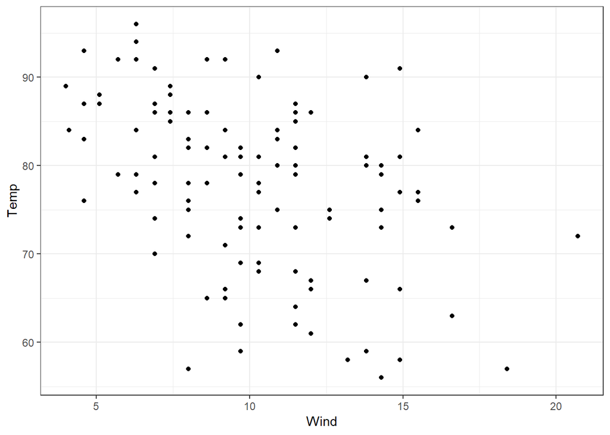

```r
TempWindplot <- ggplot(data = train_regression) +
   geom_point(aes(x=Wind, y=Temp)) +
   theme_bw()
TempWindplot
```

2. Create and fit a linear model to predict Temperature from Wind using the training set

```r
set.seed(1127)

linear_regression <- train(Temp ~ Wind, train_regression, method = "lm")
#Training a linear model to predict temperature variable based on wind variable
```

3. Vizualize how your model performed on the train data by plotting the regression line on top of the train data points.

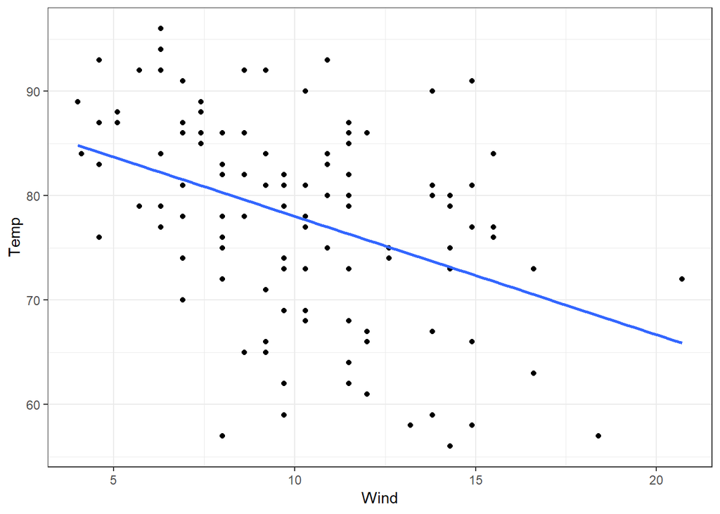

```r
fittedplot <- ggplot(data = train_regression) +
  geom_point(aes(x=Wind, y=Temp)) +
  theme_bw() +
  geom_smooth(aes(x=Wind, y=Temp), method = "lm", se = F)
fittedplot
```

```r
#Our plot with the training sample observations with a linear model regression line plotted on top.
```

4. Explore how the model performs on the test data. For Linear Regression:
- The residuals should be close to zero.
- There should be equal variance around the regression line (homoscedasticity).
- Residuals should be normally distributed.
- Independent variables and residuals should not be correlated.

4 a) See how the model performs on the test data

```r
set.seed(1127)

linear_predict <- predict(linear_regression, newdata = test_regression, method = "lm")
linear_predict
```

```
##        1        9       10       14       23       25       31       34
## 80.97826 66.57927 79.61772 77.01003 78.37057 70.54749 80.97826 71.11438
##       36       46       51       53       55       63       77       78
## 79.61772 76.32976 77.69030 87.44079 82.22541 78.93745 81.54515 77.69030
##       86       91       95      101      106      110      111      112
## 80.29799 80.97826 80.97826 80.29799 78.37057 80.97826 77.01003 77.69030
##      114      117      119      120      121      125      126      128
## 73.15518 85.51337 82.90568 78.37057 86.76053 83.58595 86.19364 80.97826
##      134      137      138      141      143      144      150
## 72.47492 77.01003 76.32976 77.69030 80.29799 75.08261 74.40234
```

```r
#These are the temperature values our linear model predicted when using the test set data.
```

4 b) Look at the residuals. Are they close to zero?

```r
summary(linear_regression, newdata = test_regression)
```

```
##
## Call:
## lm(formula = .outcome ~ ., data = dat)
##
## Residuals:
##     Min      1Q  Median      3Q     Max
## -23.298  -6.660   2.062   5.954  18.525
##
## Coefficients:
##             Estimate Std. Error t value Pr(>|t|)
## (Intercept)  89.3682     2.6116  34.220  < 2e-16 ***
## Wind         -1.1338     0.2436  -4.655 8.97e-06 ***
## ---
## Signif. codes:  0 '***' 0.001 '**' 0.01 '*' 0.05 '.' 0.1 ' ' 1
##
## Residual standard error: 8.737 on 112 degrees of freedom
## Multiple R-squared:  0.1621, Adjusted R-squared:  0.1546
## F-statistic: 21.67 on 1 and 112 DF,  p-value: 8.968e-06
```

```r
#Looking at the median residual which is about 2, that is relatively close to 0 when seeing that the maximum magnitude residual is around 23.3.
```

4 c) Plot predicted temperature vs observed temperature. A strong model should show a strong correlation

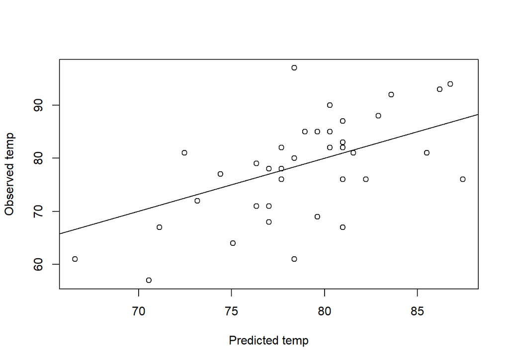

```
## integer(0)
```

```r
plot(linear_predict, test_regression$Temp, xlab = "Predicted temp", ylab = "Observed temp") + abline(a=0, b=1)
```

```r
#Plotting predicted temperature vs observed temperature with a y=x line plotted on the points for comparison.
```

```r
cor.test(linear_predict, test_regression$Temp)
```

```
##
##  Pearson's product-moment correlation
##
## data:  linear_predict and test_regression$Temp
## t = 4.6873, df = 37, p-value = 3.69e-05
## alternative hypothesis: true correlation is not equal to 0
## 95 percent confidence interval:
##  0.3652057 0.7763835
## sample estimates:
##       cor
## 0.6103885
```

```r
#We have a significant p-value of 3.69e-05, confirming that there is in fact a significant correlation between the temperatures.
```

4 d) Visualize the predicted values in relation to the real data points. Look for homoscedasticity

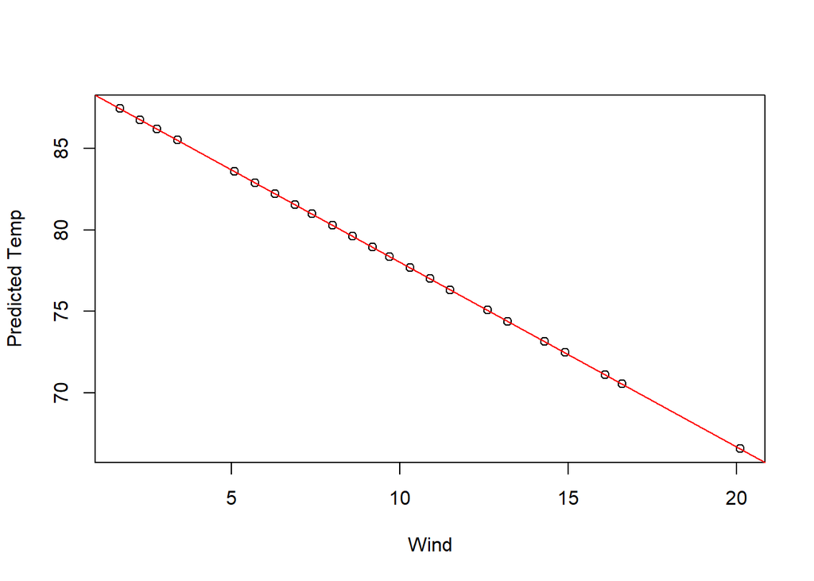

```
## integer(0)
```

```r
# Extract coefficients from the model
coeff <- linear_regression$finalModel$coefficients

# plot the regression line on the predicted values
plot(test_regression$Wind, linear_predict, xlab = "Wind", ylab = "Predicted Temp") + abline(coeff, col = "red")
```

```r
# plot the original test values
par(mar = c(4, 4, 4, 4))
plot(test_regression$Wind, linear_predict, xlab = "Wind", ylab = "Predicted Temp", pch = 16, main = "Observed and Predicted Temperatures vs. Wind") + abline(coeff, col = "red")
```

```
## integer(0)
```

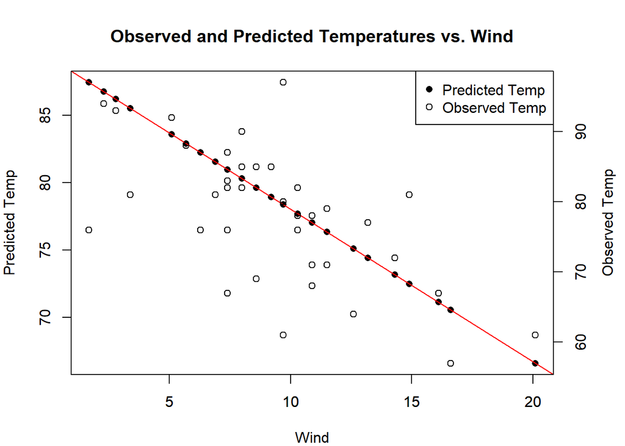

```r
par(new = T)
plot(test_regression$Wind, test_regression$Temp, xlab = "", ylab = "", yaxt = "n", pch = 21)
axis(side = 4)
mtext("Observed Temp", side = 4, line = 2.5)
legend("topright",legend=c("Predicted Temp","Observed Temp"), text.col=c("black"),pch=c(16,21),col=c("black"))
```

4 e) Residuals should be normally distributed. Plot the density of the residuals

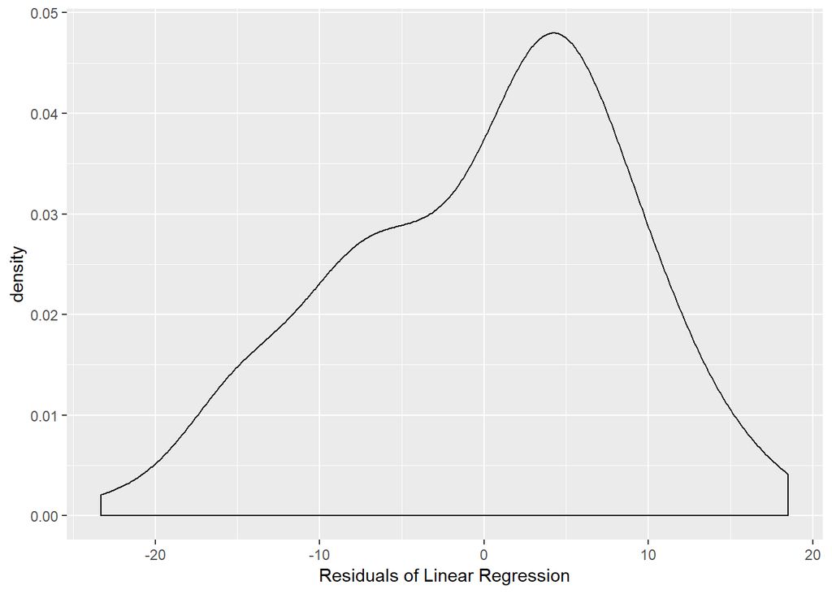

```r
residuals_lin <- residuals(linear_regression)

ggplot() +
  geom_density(aes(residuals_lin)) + xlab("Residuals of Linear Regression")
```

```r
#Plotting a density curve, it is generally normally distributed (slight bias to positive residuals).
```

4 f) Independent variables and residuals should not be correlated

```r
cor.test(train_regression$Wind, resid(linear_regression))
```

```
##
##  Pearson's product-moment correlation
##
## data:  train_regression$Wind and resid(linear_regression)
## t = -4.3467e-16, df = 112, p-value = 1
## alternative hypothesis: true correlation is not equal to 0
## 95 percent confidence interval:
##  -0.1839148  0.1839148
## sample estimates:
##           cor
## -4.107286e-17
```

```r
#Here we demonstrate a p-value of 1, signifying an insignificant correlation aka there is no correlation between our independent variable 'Wind' and our model residuals.
```

### Linear Regression with Regularization

5. Create a linear model using L1 or L2 regularization to predict Temperature from Wind and Month variables. Plot your predicted values and the real Y values on the same plot.

```r
set.seed(1127)
ctrl =  trainControl(method = "boot", 15)
ridge_model <- train(Temp ~ Wind + Month, data = train_regression, method = "ridge", trControl= ctrl)

ridge_predict <- predict(ridge_model, newdata = test_regression)
#Setting up our new model and predictions, this time using Ridge Regularization to predict Temp from Wind and Month variables.
```

```r
par(mar = c(4, 4, 4, 4))
plot(test_regression$Wind, ridge_predict, xlab = "Wind", ylab = "Predicted Temp", pch = 19, main = "Observed and Predicted Temperatures vs. Wind", col = test_regression$Month) + abline(coeff, col = "red")
```

```
## integer(0)
```

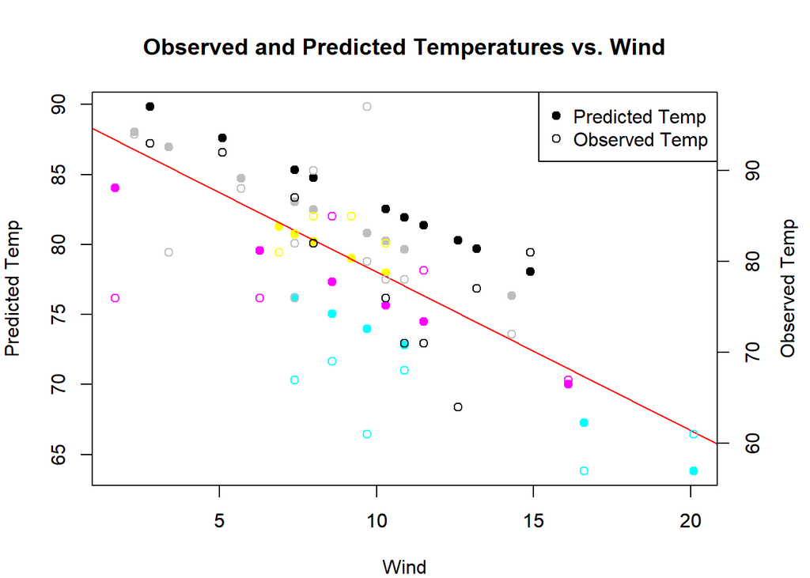

```r
par(new = T)
plot(test_regression$Wind, test_regression$Temp, xlab = "", ylab = "", yaxt = "n", pch = 21, col = test_regression$Month)
axis(side = 4)
mtext("Observed Temp", side = 4, line = 2.5)
legend("topright",legend=c("Predicted Temp","Observed Temp"), text.col=c("black"),pch=c(19, 21),col=c("black"))
```

```r
##Here we see our linear model fitted on both our predicted and observed temperatures. We see 5 different colors, confirming a general different between the 5 months our data is from. Our model has less bias now and fits our observed data better.
```